# R Notebook

This is a document describing the process of creating a basemap for the Chehalis in R. The hope is this can be used as a starting point and/or context for displays of any spatial data.

```r
# For data analysis
library(tidyverse)
# For plotting
library(ggplot2)
# To read and manipulate spatial data
library(sf)
# To add scalebar and north arrow
# Have to install the package version from github on first install (as of 12/12/2018)
#library(devtools)
#install_github("oswaldosantos/ggsn")
library(ggsn)
```

The next step is to load the various layers needed. All of the layers are shapefiles located on the computer. I tried playing around with the *maps* package to load in a basemap, but found not were the maps low resolution but they came in a format that was hard to deal with. I use the bounding box *st_bbox()* function to clip the state of washington to the Chehalis.

```r
# NOAA subbasins
sub <- st_read('../../Inputs/shapefiles/NOAA_subbasins_w_fp.shp')
# Bounding box for the basemap data
buffer <- 1e4 # buffer of X meters
bbox <- st_bbox(sub) + c(-buffer, -buffer, buffer, buffer) # subtract from the xmin and ymin, add to the xmax and ymax
# Path to WA state shapefile
wa_state <- '//nwcfile/FE/watershed/Chehalis/Data/Map files/washington.shp'
# State of Washington -- land only
wa <- st_read(wa_state) %>%
  filter(CARTO_SYMB == 1) %>% # This field means 'land'
  st_transform(crs = st_crs(sub)) %>% # Reproject into the coordinate refrence system of the layer 'sub' (NAD83 Zone 10)
  st_crop(bbox)
```

```
attribute variables are assumed to be spatially constant throughout all geometries
```

```r
# State of Washington -- water only
water <- st_read(wa_state) %>%
  filter(CARTO_SYMB == 4) %>%
  st_transform(st_crs(sub)) %>%
  st_crop(bbox)
```

```
attribute variables are assumed to be spatially constant throughout all geometries
```

Now put it all together to create a basemap.

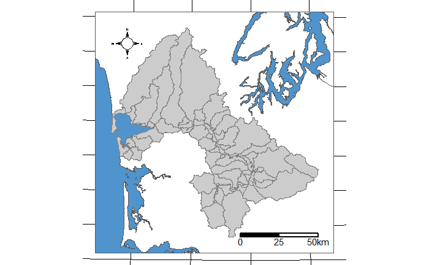

```r
basemap <- ggplot() +
  theme_void() +
  geom_sf(data = water, fill = 'steelblue3') +
  geom_sf(data = wa, fill = 'white') +
  geom_sf(data = sub, fill = 'grey80', color = 'grey50') +
  #coord_sf(datum = NA) +
  ggsn::north(sub, symbol = 16, scale = 0.15, location = 'topleft') +
  ggsn::scalebar(data = sub, dist = 25, location = "bottomright", dd2km = F, st.size = 4)
basemap
```

```r
fl <- st_read('../../Inputs/shapefiles/flowline.shp') %>%
  gather(species, presence, EDT_FChino:EDT_Chum) %>%
  filter(presence == 'Yes')
```

Try it with a facet wrap. Takes ~10 min to render…

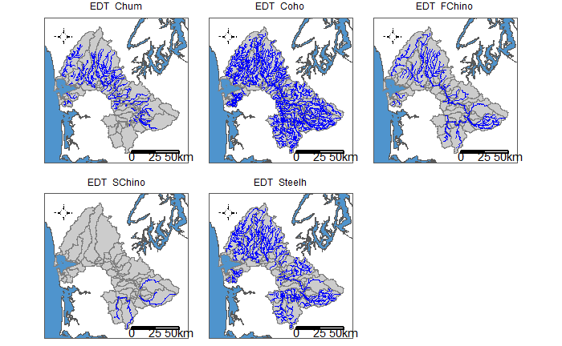